# Risk Factor Analysis

## Outcome Variable

**Outcome Variable:** y_rate_haz

## Predictor Variables

**Intervention Variable:** predfeed36

**Adjustment Set:**

- arm
- sex
- month
- brthmon
- W_mage
- meducyrs
- feducyrs
- hhwealth_quart
- hfoodsec
- W_mhtcm
- W_mwtkg
- W_mbmi
- vagbrth
- W_birthwt
- W_birthlen
- single
- W_nrooms
- impfloor
- impsan
- safeh20
- delta_W_mage
- delta_meducyrs
- delta_feducyrs
- delta_hhwealth_quart
- delta_hfoodsec
- delta_W_mhtcm
- delta_W_mwtkg
- delta_W_mbmi
- delta_vagbrth
- delta_W_birthwt
- delta_W_birthlen
- delta_single
- delta_W_nrooms
- delta_impfloor
- delta_impsan
- delta_safeh20

## Stratifying Variables

The analysis was stratified on these variable(s):

- agecat
- studyid
- country

## Data Summary

| agecat | studyid | country | predfeed36 | n_cell | n | outcome_variable |
| --- | --- | --- | --- | --- | --- | --- |
| 0-3 months | ki0047075b-MAL-ED | BANGLADESH | 1 | 81 | 242 | y_rate_haz |
| 0-3 months | ki0047075b-MAL-ED | BANGLADESH | 0 | 161 | 242 | y_rate_haz |
| 0-3 months | ki0047075b-MAL-ED | BRAZIL | 1 | 19 | 167 | y_rate_haz |
| 0-3 months | ki0047075b-MAL-ED | BRAZIL | 0 | 148 | 167 | y_rate_haz |
| 0-3 months | ki0047075b-MAL-ED | INDIA | 1 | 11 | 181 | y_rate_haz |
| 0-3 months | ki0047075b-MAL-ED | INDIA | 0 | 170 | 181 | y_rate_haz |
| 0-3 months | ki0047075b-MAL-ED | NEPAL | 1 | 8 | 154 | y_rate_haz |
| 0-3 months | ki0047075b-MAL-ED | NEPAL | 0 | 146 | 154 | y_rate_haz |
| 0-3 months | ki0047075b-MAL-ED | PERU | 1 | 69 | 263 | y_rate_haz |
| 0-3 months | ki0047075b-MAL-ED | PERU | 0 | 194 | 263 | y_rate_haz |
| 0-3 months | ki0047075b-MAL-ED | SOUTH AFRICA | 1 | 1 | 209 | y_rate_haz |
| 0-3 months | ki0047075b-MAL-ED | SOUTH AFRICA | 0 | 208 | 209 | y_rate_haz |
| 0-3 months | ki0047075b-MAL-ED | TANZANIA, UNITED REPUBLIC OF | 1 | 3 | 223 | y_rate_haz |
| 0-3 months | ki0047075b-MAL-ED | TANZANIA, UNITED REPUBLIC OF | 0 | 220 | 223 | y_rate_haz |
| 0-3 months | ki1000109-EE | PAKISTAN | 1 | 2 | 6 | y_rate_haz |
| 0-3 months | ki1000109-EE | PAKISTAN | 0 | 4 | 6 | y_rate_haz |
| 0-3 months | ki1113344-GMS-Nepal | NEPAL | 1 | 372 | 465 | y_rate_haz |
| 0-3 months | ki1113344-GMS-Nepal | NEPAL | 0 | 93 | 465 | y_rate_haz |
| 0-3 months | kiGH5241-JiVitA-3 | BANGLADESH | 1 | 7584 | 9726 | y_rate_haz |
| 0-3 months | kiGH5241-JiVitA-3 | BANGLADESH | 0 | 2142 | 9726 | y_rate_haz |
| 0-3 months | kiGH5241-JiVitA-4 | BANGLADESH | 1 | 1920 | 2307 | y_rate_haz |
| 0-3 months | kiGH5241-JiVitA-4 | BANGLADESH | 0 | 387 | 2307 | y_rate_haz |
| 3-6 months | ki0047075b-MAL-ED | BANGLADESH | 1 | 77 | 230 | y_rate_haz |
| 3-6 months | ki0047075b-MAL-ED | BANGLADESH | 0 | 153 | 230 | y_rate_haz |
| 3-6 months | ki0047075b-MAL-ED | BRAZIL | 1 | 25 | 208 | y_rate_haz |
| 3-6 months | ki0047075b-MAL-ED | BRAZIL | 0 | 183 | 208 | y_rate_haz |
| 3-6 months | ki0047075b-MAL-ED | INDIA | 1 | 17 | 228 | y_rate_haz |
| 3-6 months | ki0047075b-MAL-ED | INDIA | 0 | 211 | 228 | y_rate_haz |
| 3-6 months | ki0047075b-MAL-ED | NEPAL | 1 | 8 | 232 | y_rate_haz |
| 3-6 months | ki0047075b-MAL-ED | NEPAL | 0 | 224 | 232 | y_rate_haz |

[output cut: 150 more lines]

The following strata were considered:

- agecat: 0-3 months, studyid: ki0047075b-MAL-ED, country: BANGLADESH
- agecat: 0-3 months, studyid: ki0047075b-MAL-ED, country: BRAZIL
- agecat: 0-3 months, studyid: ki0047075b-MAL-ED, country: INDIA
- agecat: 0-3 months, studyid: ki0047075b-MAL-ED, country: NEPAL
- agecat: 0-3 months, studyid: ki0047075b-MAL-ED, country: PERU
- agecat: 0-3 months, studyid: ki0047075b-MAL-ED, country: SOUTH AFRICA
- agecat: 0-3 months, studyid: ki0047075b-MAL-ED, country: TANZANIA, UNITED REPUBLIC OF
- agecat: 0-3 months, studyid: ki1000109-EE, country: PAKISTAN
- agecat: 0-3 months, studyid: ki1113344-GMS-Nepal, country: NEPAL
- agecat: 0-3 months, studyid: kiGH5241-JiVitA-3, country: BANGLADESH
- agecat: 0-3 months, studyid: kiGH5241-JiVitA-4, country: BANGLADESH
- agecat: 12-15 months, studyid: ki0047075b-MAL-ED, country: BANGLADESH
- agecat: 12-15 months, studyid: ki0047075b-MAL-ED, country: BRAZIL
- agecat: 12-15 months, studyid: ki0047075b-MAL-ED, country: INDIA
- agecat: 12-15 months, studyid: ki0047075b-MAL-ED, country: NEPAL
- agecat: 12-15 months, studyid: ki0047075b-MAL-ED, country: PERU
- agecat: 12-15 months, studyid: ki0047075b-MAL-ED, country: SOUTH AFRICA
- agecat: 12-15 months, studyid: ki0047075b-MAL-ED, country: TANZANIA, UNITED REPUBLIC OF
- agecat: 12-15 months, studyid: ki1000109-EE, country: PAKISTAN
- agecat: 12-15 months, studyid: ki1000304b-SAS-FoodSuppl, country: INDIA
- agecat: 12-15 months, studyid: ki1113344-GMS-Nepal, country: NEPAL
- agecat: 12-15 months, studyid: ki1148112-LCNI-5, country: MALAWI
- agecat: 12-15 months, studyid: kiGH5241-JiVitA-4, country: BANGLADESH
- agecat: 15-18 months, studyid: ki0047075b-MAL-ED, country: BANGLADESH
- agecat: 15-18 months, studyid: ki0047075b-MAL-ED, country: BRAZIL
- agecat: 15-18 months, studyid: ki0047075b-MAL-ED, country: INDIA
- agecat: 15-18 months, studyid: ki0047075b-MAL-ED, country: NEPAL
- agecat: 15-18 months, studyid: ki0047075b-MAL-ED, country: PERU
- agecat: 15-18 months, studyid: ki0047075b-MAL-ED, country: SOUTH AFRICA
- agecat: 15-18 months, studyid: ki0047075b-MAL-ED, country: TANZANIA, UNITED REPUBLIC OF
- agecat: 15-18 months, studyid: ki1000109-EE, country: PAKISTAN
- agecat: 15-18 months, studyid: ki1000304b-SAS-FoodSuppl, country: INDIA
- agecat: 15-18 months, studyid: ki1113344-GMS-Nepal, country: NEPAL
- agecat: 15-18 months, studyid: ki1148112-LCNI-5, country: MALAWI
- agecat: 15-18 months, studyid: kiGH5241-JiVitA-4, country: BANGLADESH
- agecat: 18-21 months, studyid: ki0047075b-MAL-ED, country: BANGLADESH
- agecat: 18-21 months, studyid: ki0047075b-MAL-ED, country: BRAZIL
- agecat: 18-21 months, studyid: ki0047075b-MAL-ED, country: INDIA
- agecat: 18-21 months, studyid: ki0047075b-MAL-ED, country: NEPAL
- agecat: 18-21 months, studyid: ki0047075b-MAL-ED, country: PERU
- agecat: 18-21 months, studyid: ki0047075b-MAL-ED, country: SOUTH AFRICA
- agecat: 18-21 months, studyid: ki0047075b-MAL-ED, country: TANZANIA, UNITED REPUBLIC OF
- agecat: 18-21 months, studyid: ki1000109-EE, country: PAKISTAN
- agecat: 18-21 months, studyid: ki1113344-GMS-Nepal, country: NEPAL
- agecat: 18-21 months, studyid: ki1148112-LCNI-5, country: MALAWI
- agecat: 21-24 months, studyid: ki0047075b-MAL-ED, country: BANGLADESH
- agecat: 21-24 months, studyid: ki0047075b-MAL-ED, country: BRAZIL
- agecat: 21-24 months, studyid: ki0047075b-MAL-ED, country: INDIA
- agecat: 21-24 months, studyid: ki0047075b-MAL-ED, country: NEPAL
- agecat: 21-24 months, studyid: ki0047075b-MAL-ED, country: PERU
- agecat: 21-24 months, studyid: ki0047075b-MAL-ED, country: SOUTH AFRICA
- agecat: 21-24 months, studyid: ki0047075b-MAL-ED, country: TANZANIA, UNITED REPUBLIC OF
- agecat: 21-24 months, studyid: ki1000109-EE, country: PAKISTAN
- agecat: 21-24 months, studyid: ki1113344-GMS-Nepal, country: NEPAL
- agecat: 21-24 months, studyid: ki1148112-LCNI-5, country: MALAWI
- agecat: 3-6 months, studyid: ki0047075b-MAL-ED, country: BANGLADESH
- agecat: 3-6 months, studyid: ki0047075b-MAL-ED, country: BRAZIL
- agecat: 3-6 months, studyid: ki0047075b-MAL-ED, country: INDIA
- agecat: 3-6 months, studyid: ki0047075b-MAL-ED, country: NEPAL
- agecat: 3-6 months, studyid: ki0047075b-MAL-ED, country: PERU
- agecat: 3-6 months, studyid: ki0047075b-MAL-ED, country: SOUTH AFRICA
- agecat: 3-6 months, studyid: ki0047075b-MAL-ED, country: TANZANIA, UNITED REPUBLIC OF
- agecat: 3-6 months, studyid: ki1000109-EE, country: PAKISTAN
- agecat: 3-6 months, studyid: ki1113344-GMS-Nepal, country: NEPAL
- agecat: 3-6 months, studyid: kiGH5241-JiVitA-3, country: BANGLADESH
- agecat: 3-6 months, studyid: kiGH5241-JiVitA-4, country: BANGLADESH
- agecat: 6-9 months, studyid: ki0047075b-MAL-ED, country: BANGLADESH
- agecat: 6-9 months, studyid: ki0047075b-MAL-ED, country: BRAZIL
- agecat: 6-9 months, studyid: ki0047075b-MAL-ED, country: INDIA
- agecat: 6-9 months, studyid: ki0047075b-MAL-ED, country: NEPAL
- agecat: 6-9 months, studyid: ki0047075b-MAL-ED, country: PERU
- agecat: 6-9 months, studyid: ki0047075b-MAL-ED, country: SOUTH AFRICA
- agecat: 6-9 months, studyid: ki0047075b-MAL-ED, country: TANZANIA, UNITED REPUBLIC OF
- agecat: 6-9 months, studyid: ki1000109-EE, country: PAKISTAN
- agecat: 6-9 months, studyid: ki1000304b-SAS-FoodSuppl, country: INDIA
- agecat: 6-9 months, studyid: ki1113344-GMS-Nepal, country: NEPAL
- agecat: 6-9 months, studyid: ki1148112-LCNI-5, country: MALAWI
- agecat: 6-9 months, studyid: kiGH5241-JiVitA-4, country: BANGLADESH
- agecat: 9-12 months, studyid: ki0047075b-MAL-ED, country: BANGLADESH
- agecat: 9-12 months, studyid: ki0047075b-MAL-ED, country: BRAZIL
- agecat: 9-12 months, studyid: ki0047075b-MAL-ED, country: INDIA
- agecat: 9-12 months, studyid: ki0047075b-MAL-ED, country: NEPAL
- agecat: 9-12 months, studyid: ki0047075b-MAL-ED, country: PERU
- agecat: 9-12 months, studyid: ki0047075b-MAL-ED, country: SOUTH AFRICA
- agecat: 9-12 months, studyid: ki0047075b-MAL-ED, country: TANZANIA, UNITED REPUBLIC OF
- agecat: 9-12 months, studyid: ki1000109-EE, country: PAKISTAN
- agecat: 9-12 months, studyid: ki1000304b-SAS-FoodSuppl, country: INDIA
- agecat: 9-12 months, studyid: ki1113344-GMS-Nepal, country: NEPAL
- agecat: 9-12 months, studyid: ki1148112-LCNI-5, country: MALAWI
- agecat: 9-12 months, studyid: kiGH5241-JiVitA-4, country: BANGLADESH

### Dropped Strata

Some strata were dropped due to rare outcomes:

- agecat: 0-3 months, studyid: ki0047075b-MAL-ED, country: SOUTH AFRICA
- agecat: 0-3 months, studyid: ki0047075b-MAL-ED, country: TANZANIA, UNITED REPUBLIC OF
- agecat: 0-3 months, studyid: ki1000109-EE, country: PAKISTAN
- agecat: 3-6 months, studyid: ki0047075b-MAL-ED, country: SOUTH AFRICA
- agecat: 3-6 months, studyid: ki1000109-EE, country: PAKISTAN
- agecat: 6-9 months, studyid: ki0047075b-MAL-ED, country: SOUTH AFRICA
- agecat: 6-9 months, studyid: ki1000109-EE, country: PAKISTAN
- agecat: 6-9 months, studyid: ki1000304b-SAS-FoodSuppl, country: INDIA
- agecat: 9-12 months, studyid: ki0047075b-MAL-ED, country: SOUTH AFRICA
- agecat: 9-12 months, studyid: ki0047075b-MAL-ED, country: TANZANIA, UNITED REPUBLIC OF
- agecat: 9-12 months, studyid: ki1000109-EE, country: PAKISTAN
- agecat: 9-12 months, studyid: ki1000304b-SAS-FoodSuppl, country: INDIA
- agecat: 12-15 months, studyid: ki0047075b-MAL-ED, country: SOUTH AFRICA
- agecat: 12-15 months, studyid: ki0047075b-MAL-ED, country: TANZANIA, UNITED REPUBLIC OF
- agecat: 12-15 months, studyid: ki1000109-EE, country: PAKISTAN
- agecat: 12-15 months, studyid: ki1000304b-SAS-FoodSuppl, country: INDIA
- agecat: 12-15 months, studyid: ki1148112-LCNI-5, country: MALAWI
- agecat: 15-18 months, studyid: ki0047075b-MAL-ED, country: SOUTH AFRICA
- agecat: 15-18 months, studyid: ki0047075b-MAL-ED, country: TANZANIA, UNITED REPUBLIC OF
- agecat: 15-18 months, studyid: ki1000109-EE, country: PAKISTAN
- agecat: 15-18 months, studyid: ki1000304b-SAS-FoodSuppl, country: INDIA
- agecat: 15-18 months, studyid: ki1148112-LCNI-5, country: MALAWI
- agecat: 18-21 months, studyid: ki0047075b-MAL-ED, country: SOUTH AFRICA
- agecat: 18-21 months, studyid: ki0047075b-MAL-ED, country: TANZANIA, UNITED REPUBLIC OF
- agecat: 18-21 months, studyid: ki1000109-EE, country: PAKISTAN
- agecat: 21-24 months, studyid: ki0047075b-MAL-ED, country: SOUTH AFRICA
- agecat: 21-24 months, studyid: ki0047075b-MAL-ED, country: TANZANIA, UNITED REPUBLIC OF
- agecat: 21-24 months, studyid: ki1000109-EE, country: PAKISTAN

## Methods Detail

We’re interested in the causal parameters $E[Y_a]$ for all values of $a \in \mathcal{A}$. These parameters represent the mean outcome if, possibly contrary to fact, we intervened to set all units to have $A=a$. Under the randomization and positivity assumptions, these are identified by the statistical parameters $\psi_a=E_W[E_{Y|A,W}(Y|A=a,W)]$. In addition, we’re interested in the mean of $Y$, $E[Y]$ under no intervention (the observed mean). We will estimate these parameters by using SuperLearner to fit the relevant likelihood factors – $E_{Y|A,W}(Y|A=a,W)$ and $p(A=a|W)$, and then updating our likelihood fit using a joint TMLE.

For unadjusted analyses ($W=\{\}$), initial likelihoods were estimated using Lrnr_glm to estimate the simple $E(Y|A)$ and Lrnr_mean to estimate $p(A)$. For adjusted analyses, a small library containing Lrnr_glmnet, Lrnr_xgboost, and Lrnr_mean was used.

# Results Detail

## Results Plots

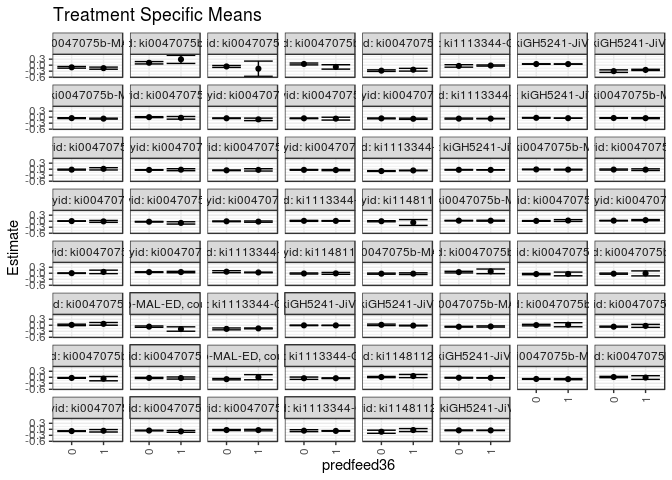

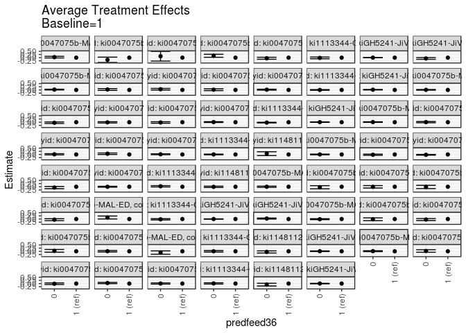

[figure not shown]

## Results Table

### Parameter: TSM

| agecat | studyid | country | intervention_level | baseline_level | estimate | ci_lower | ci_upper |
| --- | --- | --- | --- | --- | --- | --- | --- |
| 0-3 months | ki0047075b-MAL-ED | BANGLADESH | 1 | NA | -0.1489436 | -0.2016883 | -0.0961990 |
| 0-3 months | ki0047075b-MAL-ED | BANGLADESH | 0 | NA | -0.1089509 | -0.1512538 | -0.0666480 |
| 0-3 months | ki0047075b-MAL-ED | BRAZIL | 1 | NA | 0.2883822 | 0.0869029 | 0.4898616 |
| 0-3 months | ki0047075b-MAL-ED | BRAZIL | 0 | NA | 0.1196906 | 0.0608998 | 0.1784814 |
| 0-3 months | ki0047075b-MAL-ED | INDIA | 1 | NA | -0.1766788 | -0.5559100 | 0.2025524 |
| 0-3 months | ki0047075b-MAL-ED | INDIA | 0 | NA | -0.0649193 | -0.1132444 | -0.0165942 |
| 0-3 months | ki0047075b-MAL-ED | NEPAL | 1 | NA | -0.0889117 | -0.1986958 | 0.0208725 |
| 0-3 months | ki0047075b-MAL-ED | NEPAL | 0 | NA | 0.0598120 | 0.0134670 | 0.1061569 |
| 0-3 months | ki0047075b-MAL-ED | PERU | 1 | NA | -0.2281396 | -0.2961618 | -0.1601174 |
| 0-3 months | ki0047075b-MAL-ED | PERU | 0 | NA | -0.2752990 | -0.3148114 | -0.2357867 |
| 0-3 months | ki1113344-GMS-Nepal | NEPAL | 1 | NA | -0.0195537 | -0.0479226 | 0.0088152 |
| 0-3 months | ki1113344-GMS-Nepal | NEPAL | 0 | NA | -0.0390857 | -0.1014308 | 0.0232594 |
| 0-3 months | kiGH5241-JiVitA-3 | BANGLADESH | 1 | NA | 0.0542125 | 0.0473259 | 0.0610991 |
| 0-3 months | kiGH5241-JiVitA-3 | BANGLADESH | 0 | NA | 0.0557337 | 0.0434568 | 0.0680106 |
| 0-3 months | kiGH5241-JiVitA-4 | BANGLADESH | 1 | NA | -0.2373835 | -0.2666068 | -0.2081602 |
| 0-3 months | kiGH5241-JiVitA-4 | BANGLADESH | 0 | NA | -0.2989231 | -0.3621243 | -0.2357218 |
| 3-6 months | ki0047075b-MAL-ED | BANGLADESH | 1 | NA | -0.0219364 | -0.0623293 | 0.0184565 |
| 3-6 months | ki0047075b-MAL-ED | BANGLADESH | 0 | NA | -0.0228736 | -0.0511183 | 0.0053711 |
| 3-6 months | ki0047075b-MAL-ED | BRAZIL | 1 | NA | 0.0941483 | -0.0217234 | 0.2100200 |
| 3-6 months | ki0047075b-MAL-ED | BRAZIL | 0 | NA | 0.0558087 | 0.0159342 | 0.0956831 |
| 3-6 months | ki0047075b-MAL-ED | INDIA | 1 | NA | -0.0356247 | -0.1279398 | 0.0566904 |
| 3-6 months | ki0047075b-MAL-ED | INDIA | 0 | NA | -0.0410903 | -0.0719452 | -0.0102353 |
| 3-6 months | ki0047075b-MAL-ED | NEPAL | 1 | NA | -0.0082546 | -0.1325394 | 0.1160303 |
| 3-6 months | ki0047075b-MAL-ED | NEPAL | 0 | NA | -0.0227604 | -0.0500178 | 0.0044970 |
| 3-6 months | ki0047075b-MAL-ED | PERU | 1 | NA | 0.0698028 | 0.0027469 | 0.1368588 |
| 3-6 months | ki0047075b-MAL-ED | PERU | 0 | NA | 0.0177205 | -0.0174900 | 0.0529310 |
| 3-6 months | ki0047075b-MAL-ED | TANZANIA, UNITED REPUBLIC OF | 1 | NA | -0.1893761 | -0.2987707 | -0.0799816 |
| 3-6 months | ki0047075b-MAL-ED | TANZANIA, UNITED REPUBLIC OF | 0 | NA | -0.0688887 | -0.1019762 | -0.0358013 |
| 3-6 months | ki1113344-GMS-Nepal | NEPAL | 1 | NA | -0.1582116 | -0.1787595 | -0.1376637 |
| 3-6 months | ki1113344-GMS-Nepal | NEPAL | 0 | NA | -0.1817842 | -0.2283736 | -0.1351947 |

[output cut: 94 more lines]

### Parameter: E(Y)

| agecat | studyid | country | intervention_level | baseline_level | estimate | ci_lower | ci_upper |
| --- | --- | --- | --- | --- | --- | --- | --- |
| 0-3 months | ki0047075b-MAL-ED | BANGLADESH | NA | NA | -0.1219910 | -0.1558661 | -0.0881159 |
| 0-3 months | ki0047075b-MAL-ED | BRAZIL | NA | NA | 0.1392055 | 0.0825938 | 0.1958172 |
| 0-3 months | ki0047075b-MAL-ED | INDIA | NA | NA | -0.0580126 | -0.1086434 | -0.0073818 |
| 0-3 months | ki0047075b-MAL-ED | NEPAL | NA | NA | 0.0520861 | 0.0074724 | 0.0966997 |
| 0-3 months | ki0047075b-MAL-ED | PERU | NA | NA | -0.2652050 | -0.2992408 | -0.2311692 |
| 0-3 months | ki1113344-GMS-Nepal | NEPAL | NA | NA | -0.0244364 | -0.0506014 | 0.0017286 |
| 0-3 months | kiGH5241-JiVitA-3 | BANGLADESH | NA | NA | 0.0545297 | 0.0481073 | 0.0609521 |
| 0-3 months | kiGH5241-JiVitA-4 | BANGLADESH | NA | NA | -0.2476806 | -0.2745201 | -0.2208411 |
| 3-6 months | ki0047075b-MAL-ED | BANGLADESH | NA | NA | -0.0232296 | -0.0468728 | 0.0004136 |
| 3-6 months | ki0047075b-MAL-ED | BRAZIL | NA | NA | 0.0597292 | 0.0232017 | 0.0962566 |
| 3-6 months | ki0047075b-MAL-ED | INDIA | NA | NA | -0.0395718 | -0.0688631 | -0.0102806 |
| 3-6 months | ki0047075b-MAL-ED | NEPAL | NA | NA | -0.0222602 | -0.0489265 | 0.0044061 |
| 3-6 months | ki0047075b-MAL-ED | PERU | NA | NA | 0.0257461 | -0.0055184 | 0.0570106 |
| 3-6 months | ki0047075b-MAL-ED | TANZANIA, UNITED REPUBLIC OF | NA | NA | -0.0714523 | -0.1039048 | -0.0389998 |
| 3-6 months | ki1113344-GMS-Nepal | NEPAL | NA | NA | -0.1619144 | -0.1807661 | -0.1430628 |
| 3-6 months | kiGH5241-JiVitA-3 | BANGLADESH | NA | NA | -0.0062187 | -0.0128267 | 0.0003893 |
| 3-6 months | kiGH5241-JiVitA-4 | BANGLADESH | NA | NA | -0.0104148 | -0.0243612 | 0.0035317 |
| 6-9 months | ki0047075b-MAL-ED | BANGLADESH | NA | NA | -0.0700232 | -0.0872813 | -0.0527650 |
| 6-9 months | ki0047075b-MAL-ED | BRAZIL | NA | NA | 0.0087834 | -0.0260798 | 0.0436466 |
| 6-9 months | ki0047075b-MAL-ED | INDIA | NA | NA | -0.0730606 | -0.0957376 | -0.0503836 |
| 6-9 months | ki0047075b-MAL-ED | NEPAL | NA | NA | -0.0338250 | -0.0531307 | -0.0145193 |
| 6-9 months | ki0047075b-MAL-ED | PERU | NA | NA | -0.0335784 | -0.0576919 | -0.0094649 |
| 6-9 months | ki0047075b-MAL-ED | TANZANIA, UNITED REPUBLIC OF | NA | NA | -0.0923147 | -0.1258617 | -0.0587677 |
| 6-9 months | ki1113344-GMS-Nepal | NEPAL | NA | NA | -0.0452273 | -0.0630261 | -0.0274285 |
| 6-9 months | ki1148112-LCNI-5 | MALAWI | NA | NA | 0.0095862 | -0.0174314 | 0.0366037 |
| 6-9 months | kiGH5241-JiVitA-4 | BANGLADESH | NA | NA | -0.0285349 | -0.0378750 | -0.0191949 |
| 9-12 months | ki0047075b-MAL-ED | BANGLADESH | NA | NA | -0.0872054 | -0.1033675 | -0.0710433 |
| 9-12 months | ki0047075b-MAL-ED | BRAZIL | NA | NA | 0.0081784 | -0.0226414 | 0.0389982 |
| 9-12 months | ki0047075b-MAL-ED | INDIA | NA | NA | -0.0918936 | -0.1079066 | -0.0758806 |
| 9-12 months | ki0047075b-MAL-ED | NEPAL | NA | NA | -0.0626857 | -0.0796381 | -0.0457334 |
| 9-12 months | ki0047075b-MAL-ED | PERU | NA | NA | -0.0419261 | -0.0633861 | -0.0204661 |
| 9-12 months | ki1113344-GMS-Nepal | NEPAL | NA | NA | -0.0800260 | -0.0943928 | -0.0656593 |
| 9-12 months | ki1148112-LCNI-5 | MALAWI | NA | NA | -0.1052774 | -0.1637460 | -0.0468087 |
| 9-12 months | kiGH5241-JiVitA-4 | BANGLADESH | NA | NA | -0.0531058 | -0.0612606 | -0.0449509 |
| 12-15 months | ki0047075b-MAL-ED | BANGLADESH | NA | NA | -0.0557123 | -0.0712495 | -0.0401751 |
| 12-15 months | ki0047075b-MAL-ED | BRAZIL | NA | NA | -0.0030430 | -0.0256176 | 0.0195316 |
| 12-15 months | ki0047075b-MAL-ED | INDIA | NA | NA | -0.0576039 | -0.0729359 | -0.0422719 |
| 12-15 months | ki0047075b-MAL-ED | NEPAL | NA | NA | -0.0575202 | -0.0730362 | -0.0420042 |
| 12-15 months | ki0047075b-MAL-ED | PERU | NA | NA | -0.0653532 | -0.0832313 | -0.0474751 |
| 12-15 months | ki1113344-GMS-Nepal | NEPAL | NA | NA | -0.0707654 | -0.0805279 | -0.0610030 |
| 12-15 months | kiGH5241-JiVitA-4 | BANGLADESH | NA | NA | -0.0465550 | -0.0533118 | -0.0397982 |
| 15-18 months | ki0047075b-MAL-ED | BANGLADESH | NA | NA | -0.0457943 | -0.0592710 | -0.0323176 |
| 15-18 months | ki0047075b-MAL-ED | BRAZIL | NA | NA | -0.0203422 | -0.0414264 | 0.0007419 |
| 15-18 months | ki0047075b-MAL-ED | INDIA | NA | NA | -0.0367528 | -0.0495674 | -0.0239382 |
| 15-18 months | ki0047075b-MAL-ED | NEPAL | NA | NA | -0.0550313 | -0.0701554 | -0.0399073 |
| 15-18 months | ki0047075b-MAL-ED | PERU | NA | NA | -0.0360565 | -0.0515481 | -0.0205649 |
| 15-18 months | ki1113344-GMS-Nepal | NEPAL | NA | NA | -0.0676012 | -0.0796397 | -0.0555626 |
| 15-18 months | kiGH5241-JiVitA-4 | BANGLADESH | NA | NA | -0.0333707 | -0.0399958 | -0.0267456 |
| 18-21 months | ki0047075b-MAL-ED | BANGLADESH | NA | NA | -0.0155219 | -0.0271478 | -0.0038959 |
| 18-21 months | ki0047075b-MAL-ED | BRAZIL | NA | NA | -0.0203590 | -0.0449122 | 0.0041942 |
| 18-21 months | ki0047075b-MAL-ED | INDIA | NA | NA | 0.0047911 | -0.0066468 | 0.0162289 |
| 18-21 months | ki0047075b-MAL-ED | NEPAL | NA | NA | -0.0282730 | -0.0413517 | -0.0151944 |
| 18-21 months | ki0047075b-MAL-ED | PERU | NA | NA | -0.0081141 | -0.0233572 | 0.0071290 |
| 18-21 months | ki1113344-GMS-Nepal | NEPAL | NA | NA | 0.0158061 | 0.0032947 | 0.0283174 |
| 18-21 months | ki1148112-LCNI-5 | MALAWI | NA | NA | -0.0092283 | -0.0423286 | 0.0238719 |
| 21-24 months | ki0047075b-MAL-ED | BANGLADESH | NA | NA | 0.0256182 | 0.0134577 | 0.0377787 |
| 21-24 months | ki0047075b-MAL-ED | BRAZIL | NA | NA | 0.0164870 | 0.0004862 | 0.0324878 |
| 21-24 months | ki0047075b-MAL-ED | INDIA | NA | NA | 0.0301809 | 0.0192922 | 0.0410697 |
| 21-24 months | ki0047075b-MAL-ED | NEPAL | NA | NA | 0.0055394 | -0.0082148 | 0.0192936 |
| 21-24 months | ki0047075b-MAL-ED | PERU | NA | NA | 0.0569744 | 0.0416628 | 0.0722859 |
| 21-24 months | ki1113344-GMS-Nepal | NEPAL | NA | NA | 0.0449374 | 0.0286985 | 0.0611763 |
| 21-24 months | ki1148112-LCNI-5 | MALAWI | NA | NA | -0.0116248 | -0.0336145 | 0.0103649 |

### Parameter: ATE

| agecat | studyid | country | intervention_level | baseline_level | estimate | ci_lower | ci_upper |
| --- | --- | --- | --- | --- | --- | --- | --- |
| 0-3 months | ki0047075b-MAL-ED | BANGLADESH | 1 | 1 | 0.0000000 | 0.0000000 | 0.0000000 |
| 0-3 months | ki0047075b-MAL-ED | BANGLADESH | 0 | 1 | 0.0399927 | -0.0256034 | 0.1055889 |
| 0-3 months | ki0047075b-MAL-ED | BRAZIL | 1 | 1 | 0.0000000 | 0.0000000 | 0.0000000 |
| 0-3 months | ki0047075b-MAL-ED | BRAZIL | 0 | 1 | -0.1686916 | -0.3789197 | 0.0415364 |
| 0-3 months | ki0047075b-MAL-ED | INDIA | 1 | 1 | 0.0000000 | 0.0000000 | 0.0000000 |
| 0-3 months | ki0047075b-MAL-ED | INDIA | 0 | 1 | 0.1117595 | -0.2688896 | 0.4924085 |
| 0-3 months | ki0047075b-MAL-ED | NEPAL | 1 | 1 | 0.0000000 | 0.0000000 | 0.0000000 |
| 0-3 months | ki0047075b-MAL-ED | NEPAL | 0 | 1 | 0.1487236 | 0.0295581 | 0.2678891 |
| 0-3 months | ki0047075b-MAL-ED | PERU | 1 | 1 | 0.0000000 | 0.0000000 | 0.0000000 |
| 0-3 months | ki0047075b-MAL-ED | PERU | 0 | 1 | -0.0471594 | -0.1259441 | 0.0316253 |
| 0-3 months | ki1113344-GMS-Nepal | NEPAL | 1 | 1 | 0.0000000 | 0.0000000 | 0.0000000 |
| 0-3 months | ki1113344-GMS-Nepal | NEPAL | 0 | 1 | -0.0195320 | -0.0873571 | 0.0482930 |
| 0-3 months | kiGH5241-JiVitA-3 | BANGLADESH | 1 | 1 | 0.0000000 | 0.0000000 | 0.0000000 |
| 0-3 months | kiGH5241-JiVitA-3 | BANGLADESH | 0 | 1 | 0.0015212 | -0.0114510 | 0.0144934 |
| 0-3 months | kiGH5241-JiVitA-4 | BANGLADESH | 1 | 1 | 0.0000000 | 0.0000000 | 0.0000000 |
| 0-3 months | kiGH5241-JiVitA-4 | BANGLADESH | 0 | 1 | -0.0615396 | -0.1303914 | 0.0073123 |
| 3-6 months | ki0047075b-MAL-ED | BANGLADESH | 1 | 1 | 0.0000000 | 0.0000000 | 0.0000000 |
| 3-6 months | ki0047075b-MAL-ED | BANGLADESH | 0 | 1 | -0.0009372 | -0.0503758 | 0.0485014 |
| 3-6 months | ki0047075b-MAL-ED | BRAZIL | 1 | 1 | 0.0000000 | 0.0000000 | 0.0000000 |
| 3-6 months | ki0047075b-MAL-ED | BRAZIL | 0 | 1 | -0.0383397 | -0.1606446 | 0.0839653 |
| 3-6 months | ki0047075b-MAL-ED | INDIA | 1 | 1 | 0.0000000 | 0.0000000 | 0.0000000 |
| 3-6 months | ki0047075b-MAL-ED | INDIA | 0 | 1 | -0.0054656 | -0.1026978 | 0.0917666 |
| 3-6 months | ki0047075b-MAL-ED | NEPAL | 1 | 1 | 0.0000000 | 0.0000000 | 0.0000000 |
| 3-6 months | ki0047075b-MAL-ED | NEPAL | 0 | 1 | -0.0145058 | -0.1417445 | 0.1127329 |
| 3-6 months | ki0047075b-MAL-ED | PERU | 1 | 1 | 0.0000000 | 0.0000000 | 0.0000000 |
| 3-6 months | ki0047075b-MAL-ED | PERU | 0 | 1 | -0.0520824 | -0.1281315 | 0.0239667 |
| 3-6 months | ki0047075b-MAL-ED | TANZANIA, UNITED REPUBLIC OF | 1 | 1 | 0.0000000 | 0.0000000 | 0.0000000 |
| 3-6 months | ki0047075b-MAL-ED | TANZANIA, UNITED REPUBLIC OF | 0 | 1 | 0.1204874 | 0.0061985 | 0.2347762 |
| 3-6 months | ki1113344-GMS-Nepal | NEPAL | 1 | 1 | 0.0000000 | 0.0000000 | 0.0000000 |
| 3-6 months | ki1113344-GMS-Nepal | NEPAL | 0 | 1 | -0.0235725 | -0.0745403 | 0.0273953 |

[output cut: 94 more lines]

### Parameter: PAR

| agecat | studyid | country | intervention_level | baseline_level | estimate | ci_lower | ci_upper |
| --- | --- | --- | --- | --- | --- | --- | --- |
| 0-3 months | ki0047075b-MAL-ED | BANGLADESH | 1 | NA | 0.0269526 | -0.0169610 | 0.0708662 |
| 0-3 months | ki0047075b-MAL-ED | BRAZIL | 1 | NA | -0.1491767 | -0.3394875 | 0.0411340 |
| 0-3 months | ki0047075b-MAL-ED | INDIA | 1 | NA | 0.1186661 | -0.2412227 | 0.4785550 |
| 0-3 months | ki0047075b-MAL-ED | NEPAL | 1 | NA | 0.1409977 | 0.0279017 | 0.2540937 |
| 0-3 months | ki0047075b-MAL-ED | PERU | 1 | NA | -0.0370654 | -0.0957181 | 0.0215873 |
| 0-3 months | ki1113344-GMS-Nepal | NEPAL | 1 | NA | -0.0048827 | -0.0184488 | 0.0086834 |
| 0-3 months | kiGH5241-JiVitA-3 | BANGLADESH | 1 | NA | 0.0003172 | -0.0025339 | 0.0031683 |
| 0-3 months | kiGH5241-JiVitA-4 | BANGLADESH | 1 | NA | -0.0102971 | -0.0218040 | 0.0012098 |
| 3-6 months | ki0047075b-MAL-ED | BANGLADESH | 1 | NA | -0.0012932 | -0.0341069 | 0.0315204 |
| 3-6 months | ki0047075b-MAL-ED | BRAZIL | 1 | NA | -0.0344192 | -0.1451460 | 0.0763077 |
| 3-6 months | ki0047075b-MAL-ED | INDIA | 1 | NA | -0.0039472 | -0.0943023 | 0.0864080 |
| 3-6 months | ki0047075b-MAL-ED | NEPAL | 1 | NA | -0.0140056 | -0.1368572 | 0.1088460 |
| 3-6 months | ki0047075b-MAL-ED | PERU | 1 | NA | -0.0440568 | -0.1006044 | 0.0124908 |
| 3-6 months | ki0047075b-MAL-ED | TANZANIA, UNITED REPUBLIC OF | 1 | NA | 0.1179238 | 0.0064699 | 0.2293777 |
| 3-6 months | ki1113344-GMS-Nepal | NEPAL | 1 | NA | -0.0037028 | -0.0140526 | 0.0066469 |
| 3-6 months | kiGH5241-JiVitA-3 | BANGLADESH | 1 | NA | 0.0001501 | -0.0030696 | 0.0033698 |
| 3-6 months | kiGH5241-JiVitA-4 | BANGLADESH | 1 | NA | 0.0061520 | 0.0002389 | 0.0120652 |
| 6-9 months | ki0047075b-MAL-ED | BANGLADESH | 1 | NA | -0.0085354 | -0.0342961 | 0.0172253 |
| 6-9 months | ki0047075b-MAL-ED | BRAZIL | 1 | NA | -0.0179724 | -0.1154421 | 0.0794973 |
| 6-9 months | ki0047075b-MAL-ED | INDIA | 1 | NA | -0.0417997 | -0.1141830 | 0.0305835 |
| 6-9 months | ki0047075b-MAL-ED | NEPAL | 1 | NA | 0.0354983 | -0.0693377 | 0.1403343 |
| 6-9 months | ki0047075b-MAL-ED | PERU | 1 | NA | 0.0040047 | -0.0394171 | 0.0474264 |
| 6-9 months | ki0047075b-MAL-ED | TANZANIA, UNITED REPUBLIC OF | 1 | NA | -0.0968657 | -0.2261989 | 0.0324675 |
| 6-9 months | ki1113344-GMS-Nepal | NEPAL | 1 | NA | 0.0016276 | -0.0097572 | 0.0130125 |
| 6-9 months | ki1148112-LCNI-5 | MALAWI | 1 | NA | -0.0514351 | -0.1226702 | 0.0198000 |
| 6-9 months | kiGH5241-JiVitA-4 | BANGLADESH | 1 | NA | 0.0008344 | -0.0038118 | 0.0054807 |
| 9-12 months | ki0047075b-MAL-ED | BANGLADESH | 1 | NA | 0.0066264 | -0.0166512 | 0.0299040 |
| 9-12 months | ki0047075b-MAL-ED | BRAZIL | 1 | NA | 0.0221199 | -0.0681122 | 0.1123521 |
| 9-12 months | ki0047075b-MAL-ED | INDIA | 1 | NA | -0.0180195 | -0.0767433 | 0.0407043 |
| 9-12 months | ki0047075b-MAL-ED | NEPAL | 1 | NA | 0.0424960 | -0.0044131 | 0.0894050 |
| 9-12 months | ki0047075b-MAL-ED | PERU | 1 | NA | -0.0013872 | -0.0345368 | 0.0317625 |
| 9-12 months | ki1113344-GMS-Nepal | NEPAL | 1 | NA | 0.0009383 | -0.0083328 | 0.0102093 |
| 9-12 months | ki1148112-LCNI-5 | MALAWI | 1 | NA | -0.0675597 | -0.1422785 | 0.0071591 |
| 9-12 months | kiGH5241-JiVitA-4 | BANGLADESH | 1 | NA | 0.0009080 | -0.0032953 | 0.0051112 |
| 12-15 months | ki0047075b-MAL-ED | BANGLADESH | 1 | NA | 0.0176536 | -0.0032573 | 0.0385646 |
| 12-15 months | ki0047075b-MAL-ED | BRAZIL | 1 | NA | 0.0291097 | -0.0325597 | 0.0907791 |
| 12-15 months | ki0047075b-MAL-ED | INDIA | 1 | NA | 0.0517215 | -0.0078931 | 0.1113361 |
| 12-15 months | ki0047075b-MAL-ED | NEPAL | 1 | NA | 0.0162163 | -0.0540725 | 0.0865050 |
| 12-15 months | ki0047075b-MAL-ED | PERU | 1 | NA | 0.0149591 | -0.0128754 | 0.0427936 |
| 12-15 months | ki1113344-GMS-Nepal | NEPAL | 1 | NA | -0.0000716 | -0.0053180 | 0.0051748 |
| 12-15 months | kiGH5241-JiVitA-4 | BANGLADESH | 1 | NA | 0.0034531 | -0.0005239 | 0.0074301 |
| 15-18 months | ki0047075b-MAL-ED | BANGLADESH | 1 | NA | 0.0031518 | -0.0175711 | 0.0238747 |
| 15-18 months | ki0047075b-MAL-ED | BRAZIL | 1 | NA | -0.0386984 | -0.0938921 | 0.0164953 |
| 15-18 months | ki0047075b-MAL-ED | INDIA | 1 | NA | -0.0119799 | -0.0585130 | 0.0345532 |
| 15-18 months | ki0047075b-MAL-ED | NEPAL | 1 | NA | -0.0212653 | -0.0782841 | 0.0357535 |
| 15-18 months | ki0047075b-MAL-ED | PERU | 1 | NA | 0.0067954 | -0.0173349 | 0.0309258 |
| 15-18 months | ki1113344-GMS-Nepal | NEPAL | 1 | NA | -0.0052557 | -0.0100498 | -0.0004616 |
| 15-18 months | kiGH5241-JiVitA-4 | BANGLADESH | 1 | NA | 0.0010907 | -0.0023075 | 0.0044890 |
| 18-21 months | ki0047075b-MAL-ED | BANGLADESH | 1 | NA | 0.0058366 | -0.0114661 | 0.0231394 |
| 18-21 months | ki0047075b-MAL-ED | BRAZIL | 1 | NA | 0.0040494 | -0.0403132 | 0.0484120 |
| 18-21 months | ki0047075b-MAL-ED | INDIA | 1 | NA | 0.0132924 | -0.0325637 | 0.0591484 |
| 18-21 months | ki0047075b-MAL-ED | NEPAL | 1 | NA | 0.0568451 | 0.0001733 | 0.1135169 |
| 18-21 months | ki0047075b-MAL-ED | PERU | 1 | NA | 0.0121712 | -0.0152213 | 0.0395636 |
| 18-21 months | ki1113344-GMS-Nepal | NEPAL | 1 | NA | 0.0001088 | -0.0052624 | 0.0054801 |
| 18-21 months | ki1148112-LCNI-5 | MALAWI | 1 | NA | 0.0556484 | -0.0697436 | 0.1810403 |
| 21-24 months | ki0047075b-MAL-ED | BANGLADESH | 1 | NA | 0.0001499 | -0.0188096 | 0.0191095 |
| 21-24 months | ki0047075b-MAL-ED | BRAZIL | 1 | NA | -0.0174867 | -0.0601979 | 0.0252244 |
| 21-24 months | ki0047075b-MAL-ED | INDIA | 1 | NA | -0.0236994 | -0.0522865 | 0.0048878 |
| 21-24 months | ki0047075b-MAL-ED | NEPAL | 1 | NA | -0.0603857 | -0.1450872 | 0.0243158 |
| 21-24 months | ki0047075b-MAL-ED | PERU | 1 | NA | -0.0010648 | -0.0292425 | 0.0271130 |
| 21-24 months | ki1113344-GMS-Nepal | NEPAL | 1 | NA | 0.0046603 | -0.0049523 | 0.0142728 |
| 21-24 months | ki1148112-LCNI-5 | MALAWI | 1 | NA | -0.0054894 | -0.0493173 | 0.0383384 |